## Exploring the Berkeley Grad School Dataset

### Explore the Berkeley Data set

Let’s take a look at the data:

```r
head(grad)
```

```
## # A tibble: 6 × 3
##   Program Sex   Accepted
##   <chr>   <chr> <chr>
## 1 A       Male  Yes
## 2 A       Male  Yes
## 3 A       Male  Yes
## 4 A       Male  Yes
## 5 A       Male  Yes
## 6 A       Male  Yes
```

```r
glimpse(grad)
```

```
## Rows: 1,647
## Columns: 3
## $ Program  <chr> "A", "A", "A", "A", "A", "A", "A", "A", "A", "A", "A", "A", "…
## $ Sex      <chr> "Male", "Male", "Male", "Male", "Male", "Male", "Male", "Male…
## $ Accepted <chr> "Yes", "Yes", "Yes", "Yes", "Yes", "Yes", "Yes", "Yes", "Yes"…
```

```r
table(grad$Program)
```

```
##
##   A   F
## 933 714
```

```r
table(grad$Program, grad$Sex)
```

```
##
##     Female Male
##   A    108  825
##   F    341  373
```

```r
table(grad$Accepted,grad$Sex)
```

```
##
##       Female Male
##   No     336  665
##   Yes    113  533
```

**Observational units:** *People who are applied to grad school at UC Berkeley.*

**Variables**

- **Response variable:**
  - *Accepted (binary) (yes/no)*
- **Explanatory variables:**
  - *Sex (categorical) (Male/Female)*
  - *Program (categorial) (A/F)*

Let’s change the variables to be categorical:

```r
grad2 <- grad %>% mutate(Program = as.factor(Program)) %>%
         mutate(Sex = as.factor(Sex)) %>%
         mutate(Accepted = as.factor(Accepted))
```

### Create a bar plot of accepted vs rejected.

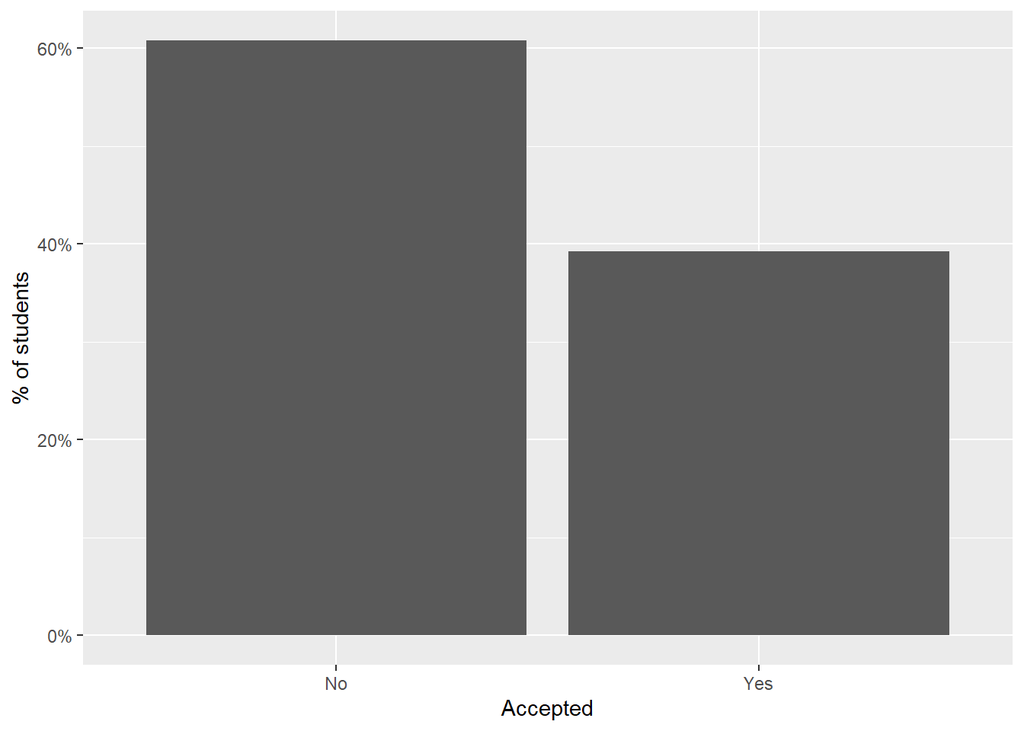

```r
acc2 <- grad2 %>% pull(Accepted) %>%
  fct_count() %>%
  mutate(perc = n / nrow(grad2))
# same as above: # acc2 <- fct_count(grad2$Accepted) %>% mutate(perc = n / nrow(grad2))
acc2 %>% ggplot(aes(x=f)) +
  geom_bar(aes(y=perc),stat = "identity") +
  labs(x="Accepted", y="% of students") +
  scale_y_continuous(labels=scales::percent)
```

What do we see here?

*Most (60%) of the applicants were rejected.*

### Create a Contingency Table

We can ask the question, “Is the admissions process at Berkeley fair?”. Or a more focused question, “Does the admissions process at Berkeley disproportionately affect women applicants?”

```r
table1(~Accepted | Sex, data=grad2)
```

|  | Female (N=449) | Male (N=1198) | Overall (N=1647) |
| --- | --- | --- | --- |
| Accepted |  |  |  |
| No | 336 (74.8%) | 665 (55.5%) | 1001 (60.8%) |
| Yes | 113 (25.2%) | 533 (44.5%) | 646 (39.2%) |

### Create Mosaic plot

Create a mosaic plot to see the data related to sex and acceptance:

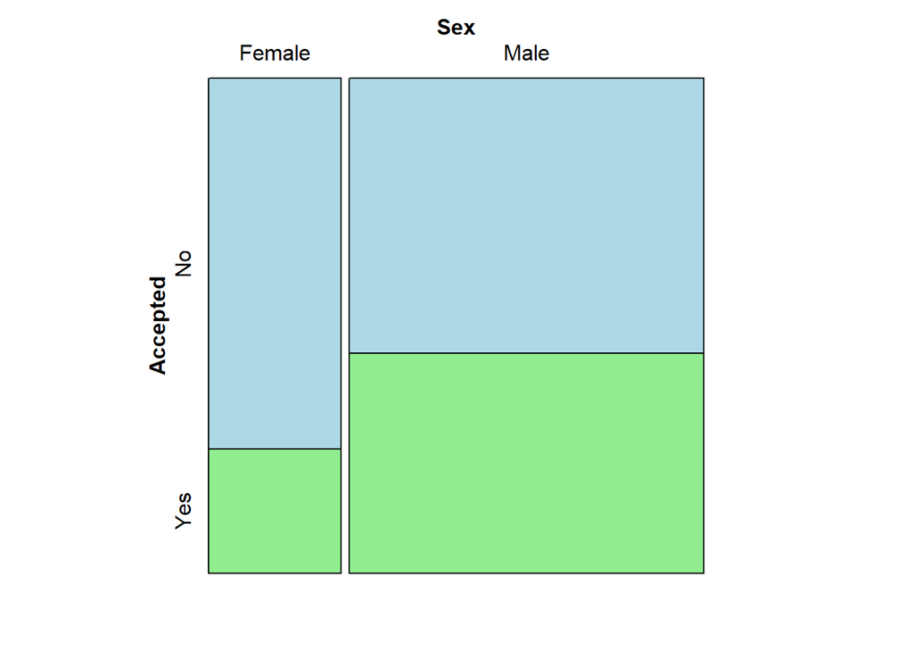

```r
# labs <- round(prop.table(table(grad2$Accepted, grad2$Sex)),2)
mosaic(~Sex+Accepted, data=grad2, highlighting="Accepted", highlighting_fill = c("lightblue", "lightgreen"), direction=c("v","h"))
```

What does this plot tell us? Are sex and acceptance *associated*?

*It looks like there are less females accepted. Also, more males applied to grad school. Sex and acceptance are associated.*

Does the program a person applied to make a difference? To explore this, we will condition on the program applied to:

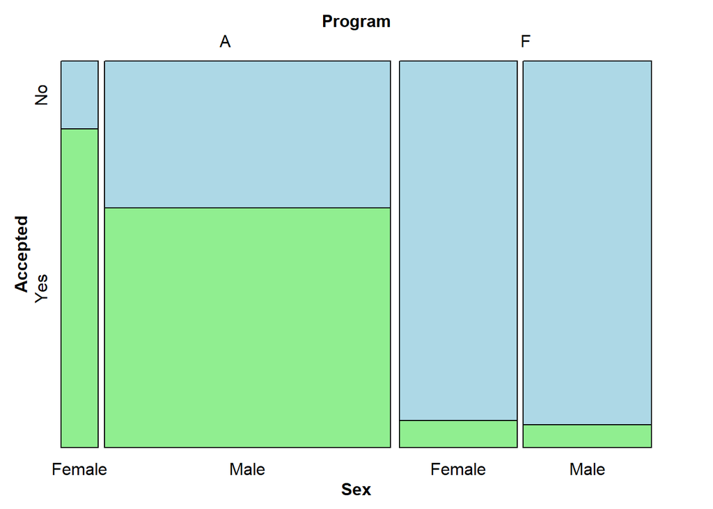

```r
mosaic(~Program+Accepted+Sex, data=grad2, highlighting="Accepted", highlighting_fill = c("lightblue", "lightgreen"), direction=c("v","h","v"))
```

What does this plot tell us? Is program associated with acceptance? How is this different than the previous plot?

*For program A, it appears that less females applied, but they were accepted at a higher rate than males. For program F, it appears that roughly an equal number of females and males applied and were accepted at roughly the same (lower) rate.* *We also see that program AND sex are associated with acceptance.*

*This is called Simpson’s paradox, where the direction of the association between sex and acceptance reverses direction.*

Here we look at the association between acceptance and program, conditioned on sex:

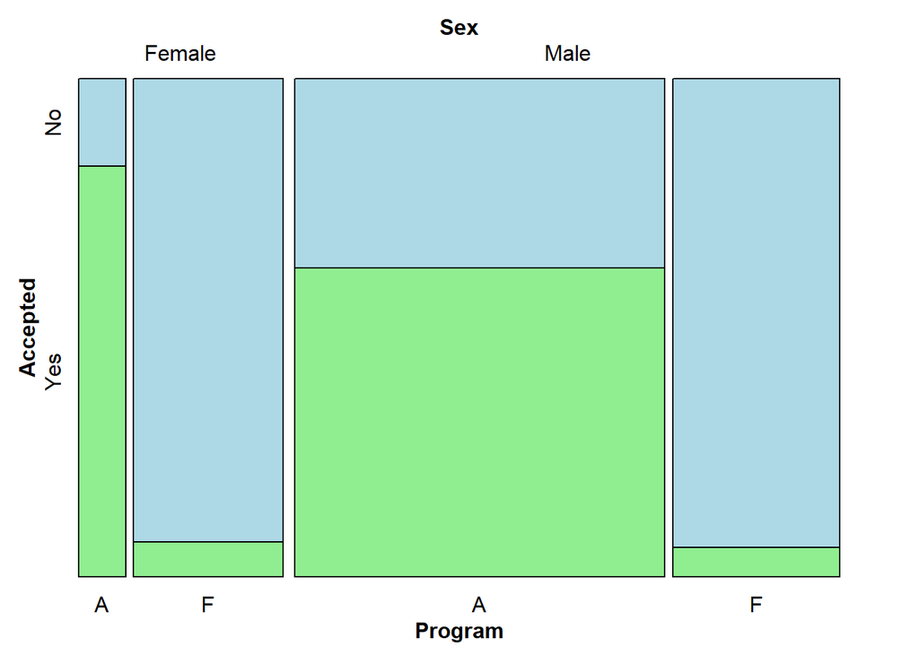

```r
mosaic(~Sex+Accepted+Program, data=grad2, highlighting="Accepted", highlighting_fill = c("lightblue", "lightgreen"), direction=c("v","h","v"))
```

What do we notice here compared to our first mosaic plot above?

*We notice that must consider the program and the sex when considering the acceptance rates for males and females.*

What can we say about our original question, “Does the admissions process at Berkeley disproportionately affect women applicants?”? What do we call the variable *program*?

*When looking only at acceptance rates and sex, we may incorrectly say that females have a disproportionate admission rate if we do not consider which program they applied to. ‘Program’ is called a confounding variable. (draw diagram if necessary)*

### Sources of Variation Diagram

On p. 8, the author provides the Sources of Variation diagram shown here.

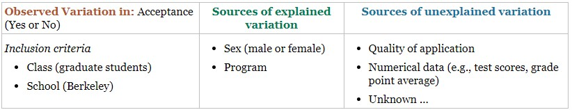

Are there other sources to consider?

Six Steps of a statistical investigation:

- Ask a Research Question
- Design a study and collect data
- Explore the data
- Draw inferences beyond the data
- Formulate conclusions
- Look back and ahead

Did we do this with the Berkeley Data? What would you tell the college administration?

Can we create a statistical model for the Berkeley data?